# Ensemble Technique Project: Travel Package Purchase Prediction

```
ProdTaken     0    1   All  PercentageOfPackageTaken
Passport
All        3968  920  4888                 18.821604
1           928  494  1422                 34.739803
0          3040  426  3466                 12.290825
------------------------------------------------------------------------------------------------------------------------
```

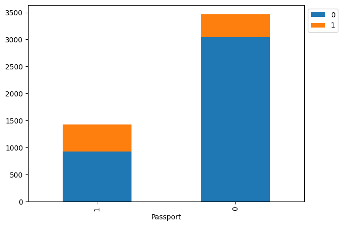

```python
stacked_barplot(data, "Passport", "ProdTaken");
```

"Visit with us" has more people with passports opting in for the package than people without passport

```
ProdTaken     0    1   All  PercentageOfPackageTaken
OwnCar
All        3968  920  4888                 18.821604
1          2472  560  3032                 18.469657
0          1496  360  1856                 19.396552
------------------------------------------------------------------------------------------------------------------------
```

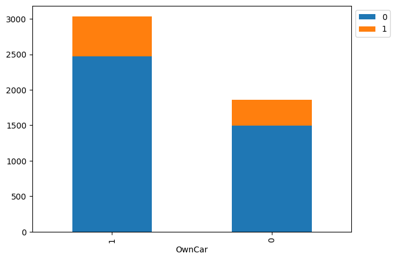

```python
stacked_barplot(data, "OwnCar", "ProdTaken");
```

```
ProdTaken                    0    1   All  PercentageOfPackageTaken
NumberOfChildrenVisiting
All                       3909  913  4822                 18.934052
1.0                       1688  392  2080                 18.846154
2.0                       1082  253  1335                 18.951311
0.0                        880  202  1082                 18.669131
3.0                        259   66   325                 20.307692
------------------------------------------------------------------------------------------------------------------------
```

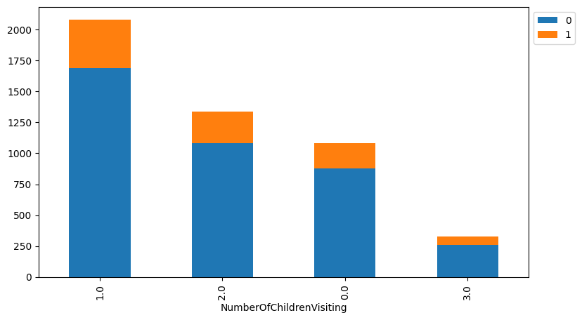

```python
stacked_barplot(data, "NumberOfChildrenVisiting", "ProdTaken");
```

The sucess rate of getting families to opt into the package does not seem to change as long as the number of kids in the families do not exceed 3. Touring parties with one kid have opted in the most.

```
ProdTaken          0    1   All  PercentageOfPackageTaken
Designation
All             3968  920  4888                 18.821604
Executive       1290  552  1842                 29.967427
Manager         1528  204  1732                 11.778291
Senior Manager   618  124   742                 16.711590
AVP              322   20   342                  5.847953
VP               210   20   230                  8.695652
------------------------------------------------------------------------------------------------------------------------
```

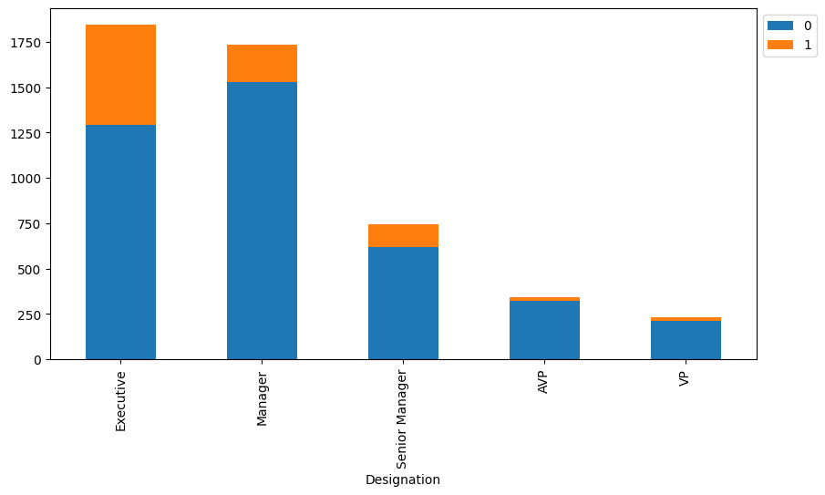

```python
stacked_barplot(data, "Designation", "ProdTaken");
```

Exectuives have opted in the most, Followed by manages and senior managers

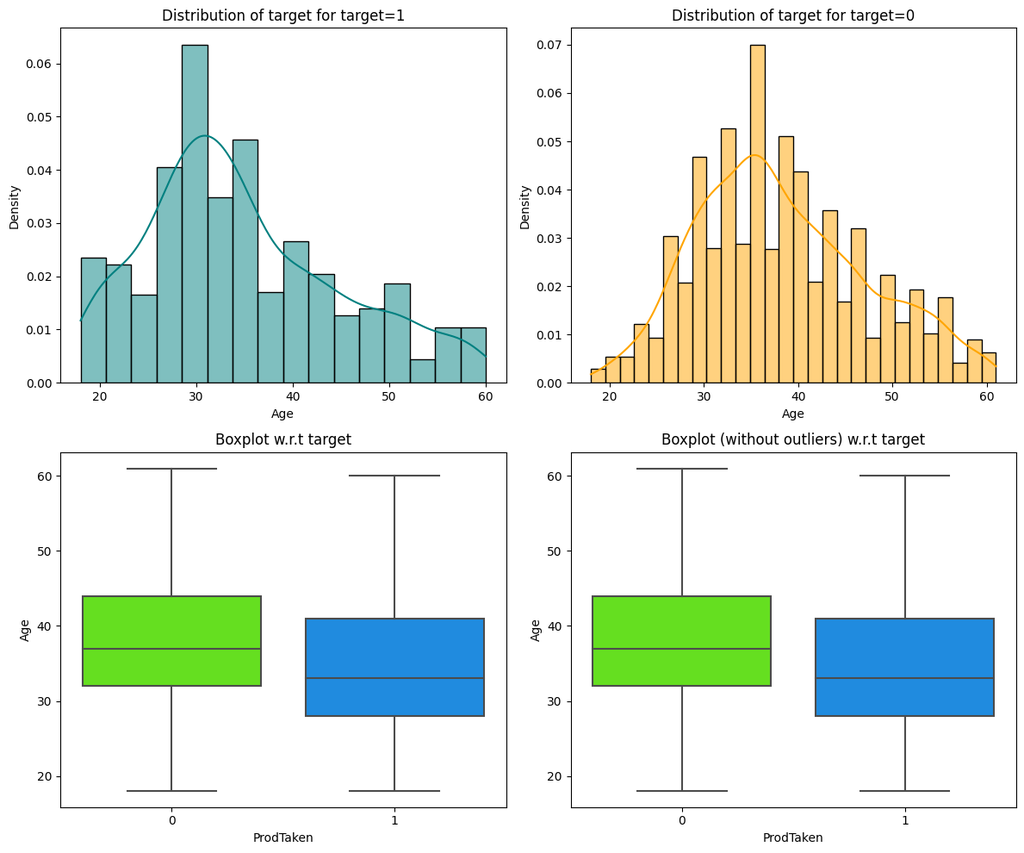

```python
distribution_plot_wrt_target(data, "Age", "ProdTaken")
```

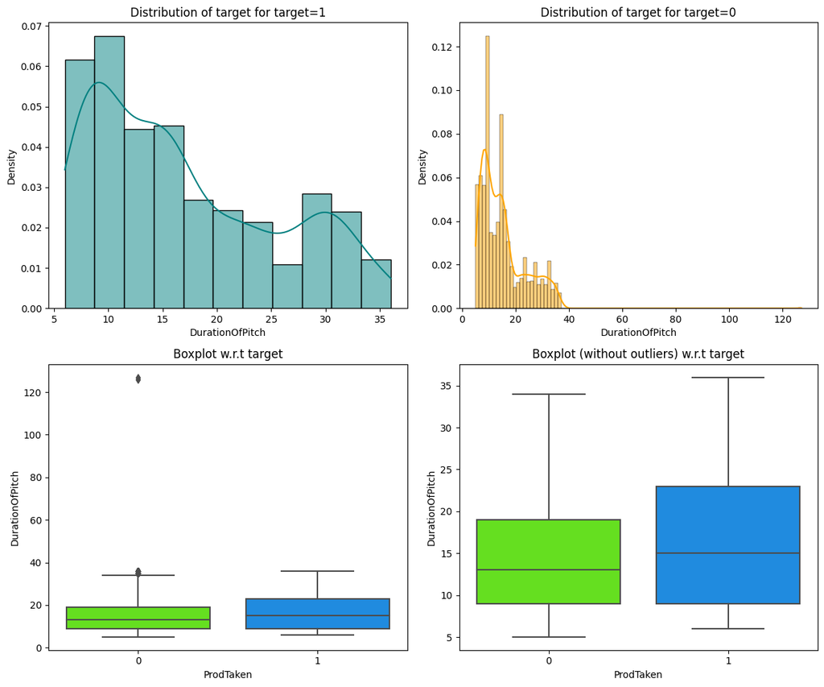

```python
distribution_plot_wrt_target(data, "DurationOfPitch", "ProdTaken")
```

Data is skewed to the right for duration of pitches

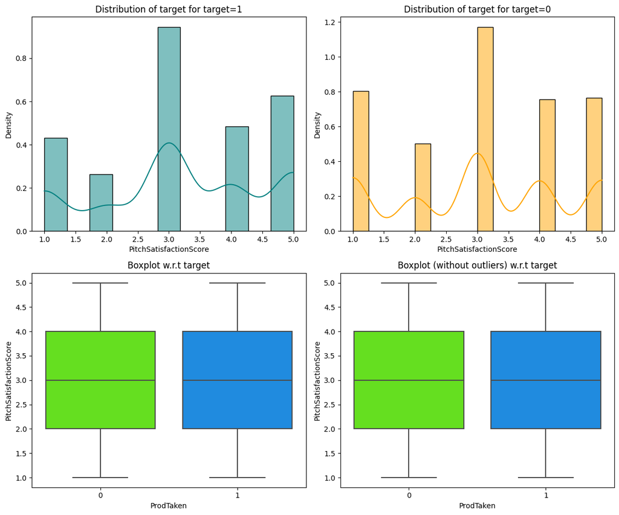

```python
distribution_plot_wrt_target(data, "PitchSatisfactionScore", "ProdTaken")
```

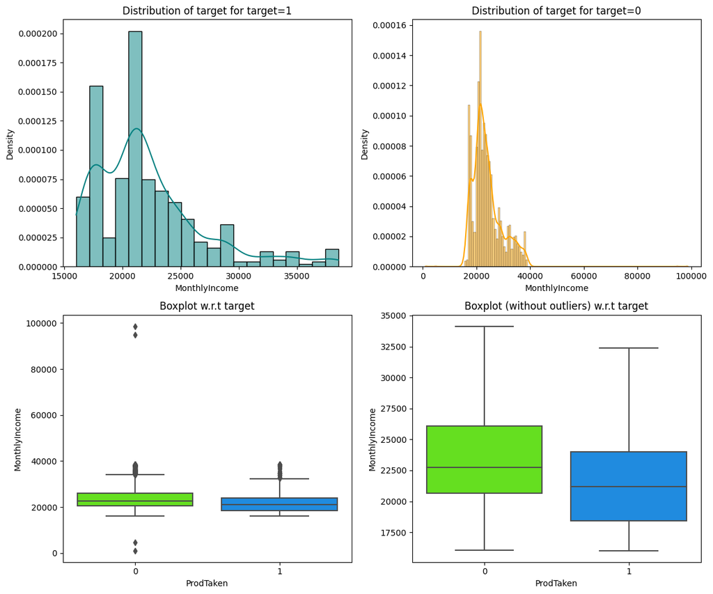

```python
distribution_plot_wrt_target(data, "MonthlyIncome", "ProdTaken")
```

Monthly income skewed to the right and has a lot of outliers.

**Questions**:

1. What is the distribution of the monthly income of customers? Are there any noticeable patterns or outliers in the distribution?
2. Which travel package is pitched the most by the salespersons to the customers?
3. How are the different customer attributes correlated to each other?
4. How does a customer's interest in purchasing the newly introduced travel package vary with their occupation?
5. How does a customer's interest in purchasing the newly introduced travel package vary with their marital status?

## Data Preprocessing

- Missing value treatment
- Feature engineering (if needed)
- Outlier detection and treatment (if needed)
- Preparing data for modeling
- Any other preprocessing steps (if needed)

```python
data.drop("CustomerID", axis=1, inplace=True)
```

```python
data.isnull().sum().sort_values(ascending=False)
```

```
DurationOfPitch             251
MonthlyIncome               233
Age                         226
NumberOfTrips               140
NumberOfChildrenVisiting     66
NumberOfFollowups            45
PreferredPropertyStar        26
TypeofContact                25
Designation                   0
OwnCar                        0
PitchSatisfactionScore        0
Passport                      0
ProdTaken                     0
MaritalStatus                 0
NumberOfPersonVisiting        0
Gender                        0
Occupation                    0
CityTier                      0
ProductPitched                0
dtype: int64
```

```python
data[data['DurationOfPitch'].isnull()]
data["DurationOfPitch"] = data["DurationOfPitch"].transform(
    lambda x: x.fillna(x.median())
)
```

```python
data["MonthlyIncome"] = data.groupby(["Occupation","Designation"])["MonthlyIncome"].transform(
    lambda x: x.fillna(x.median())
)
```

```python
data["Age"] = data.groupby(["ProdTaken","Designation"])["Age"].transform(
    lambda x: x.fillna(x.median())
)
```

```python
data["NumberOfTrips"] = data.groupby(["MaritalStatus","Age"])["NumberOfTrips"].transform(
    lambda x: x.fillna(x.median())
)
```

```python
data["NumberOfChildrenVisiting"] = data.groupby(["MaritalStatus","Age"])["NumberOfChildrenVisiting"].transform(
    lambda x: x.fillna(x.median())
)
```

```python
data["NumberOfFollowups"] = data["NumberOfFollowups"].transform(
    lambda x: x.fillna(x.median())
)
```

```python
data["PreferredPropertyStar"] = data["PreferredPropertyStar"].transform(
    lambda x: x.fillna(x.median())
)
```

```python
data["TypeofContact"] = data["TypeofContact"].transform(
    lambda x: x.fillna('Self Enquiry')
)
```

```python
data.head()
```

|  | ProdTaken | Age | TypeofContact | CityTier | DurationOfPitch | Occupation | Gender | NumberOfPersonVisiting | NumberOfFollowups | ProductPitched | PreferredPropertyStar | MaritalStatus | NumberOfTrips | Passport | PitchSatisfactionScore | OwnCar | NumberOfChildrenVisiting | Designation | MonthlyIncome |
| --- | --- | --- | --- | --- | --- | --- | --- | --- | --- | --- | --- | --- | --- | --- | --- | --- | --- | --- | --- |
| 0 | 1 | 41.0 | Self Enquiry | 3 | 6.0 | Salaried | Female | 3 | 3.0 | Deluxe | 3.0 | Single | 1.0 | 1 | 2 | 1 | 0.0 | Manager | 20993.0 |
| 1 | 0 | 49.0 | Company Invited | 1 | 14.0 | Salaried | Male | 3 | 4.0 | Deluxe | 4.0 | Divorced | 2.0 | 0 | 3 | 1 | 2.0 | Manager | 20130.0 |
| 2 | 1 | 37.0 | Self Enquiry | 1 | 8.0 | Free Lancer | Male | 3 | 4.0 | Basic | 3.0 | Single | 7.0 | 1 | 3 | 0 | 0.0 | Executive | 17090.0 |
| 3 | 0 | 33.0 | Company Invited | 1 | 9.0 | Salaried | Female | 2 | 3.0 | Basic | 3.0 | Divorced | 2.0 | 1 | 5 | 1 | 1.0 | Executive | 17909.0 |
| 4 | 0 | 33.0 | Self Enquiry | 1 | 8.0 | Small Business | Male | 2 | 3.0 | Basic | 4.0 | Divorced | 1.0 | 0 | 5 | 1 | 0.0 | Executive | 18468.0 |

```python
data['NumberOfFollowups'].value_counts()
```

```
4.0    2113
3.0    1466
5.0     768
2.0     229
1.0     176
6.0     136
Name: NumberOfFollowups, dtype: int64
```

```python
data = pd.get_dummies(data,columns=['TypeofContact','CityTier','Occupation','Gender','ProductPitched','MaritalStatus','PreferredPropertyStar','Designation'], drop_first=True)
```

```python
X = data.drop('ProdTaken', axis=1)
y = data['ProdTaken']
```

```python
# splitting in training and test set
X_train, X_test, y_train, y_test = train_test_split(X, y, test_size=0.3, random_state=1,stratify=y)
```

```python
y.value_counts(1)
```

```
0    0.811784
1    0.188216
Name: ProdTaken, dtype: float64
```

```python
y_test.value_counts(1)
```

```
0    0.811861
1    0.188139
Name: ProdTaken, dtype: float64
```

## Model Building

### Model Evaluation Criterion

1. "Visit with us" is trying to spot customers who could potentially purchase the new Wellness Tourism package
2. Emphasis should be placed on getting the positives right.
3. If we predict that the customer will buy the package and he/she ends up not buying it is loss of resources.
4. If we predict that a customer will not buy a package and he/she might have actually bought the package with the right strategy , that is loss of opportunity which is a bigger loss compare to 3.
5. This basically means Recall is a good measure to use to evaluate models

```python
# defining a function to compute different metrics to check performance of a classification model built using sklearn
def model_performance_classification_sklearn(model, predictors, target):
    """
    Function to compute different metrics to check classification model performance

    model: classifier
    predictors: independent variables
    target: dependent variable
    """

    # predicting using the independent variables
    pred = model.predict(predictors)

    acc = accuracy_score(target, pred)  # to compute Accuracy
    recall = recall_score(target, pred)  # to compute Recall
    precision = precision_score(target, pred)  # to compute Precision
    f1 = f1_score(target, pred)  # to compute F1-score

    # creating a dataframe of metrics
    df_perf = pd.DataFrame(
        {
            "Accuracy": acc,
            "Recall": recall,
            "Precision": precision,
            "F1": f1,
        },
        index=[0],
    )

    return df_perf
```

```python
def confusion_matrix_sklearn(model, predictors, target):
    """
    To plot the confusion_matrix with percentages

    model: classifier
    predictors: independent variables
    target: dependent variable
    """
    y_pred = model.predict(predictors)
    cm = confusion_matrix(target, y_pred)
    labels = np.asarray(
        [
            ["{0:0.0f}".format(item) + "\n{0:.2%}".format(item / cm.flatten().sum())]
            for item in cm.flatten()
        ]
    ).reshape(2, 2)

    plt.figure(figsize=(6, 4))
    sns.heatmap(cm, annot=labels, fmt="")
    plt.ylabel("True label")
    plt.xlabel("Predicted label")
```

### Model Building: Decision Tree

```
Training performance:
    Accuracy  Recall  Precision   F1
0       1.0     1.0        1.0  1.0
Testing performance:
    Accuracy    Recall  Precision        F1
0  0.886844  0.706522   0.696429  0.701439
```

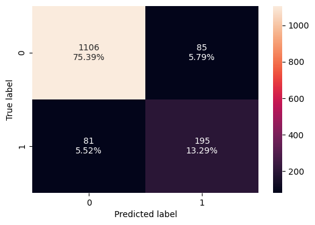

```python
#Fitting the model
d_tree_default = DecisionTreeClassifier(random_state=1)
d_tree_default.fit(X_train,y_train)

#Calculating different metrics
d_tree_model_train_perf=model_performance_classification_sklearn(d_tree_default,X_train,y_train)
print("Training performance:\n",d_tree_model_train_perf)
d_tree_model_test_perf=model_performance_classification_sklearn(d_tree_default,X_test,y_test)
print("Testing performance:\n",d_tree_model_test_perf)

#Creating confusion matrix
confusion_matrix_sklearn(d_tree_default,X_test,y_test)
```

1. Looking at the training data and the delta between training performance and testing performance, it is evident that the model is overfitting.
2. Although 13% of customers have accurately predicted as customers who would buy the pacakge, we have lost opportunity of about 81 customers which is 5%.

### Model Improvement: Decision Tree

```python
#Choose the type of classifier.
d_tree_tuned = DecisionTreeClassifier(class_weight={0:0.18,1:0.82},random_state=1)

# Grid of parameters to choose from
parameters = {'max_depth': np.arange(2,30),
              'min_samples_leaf': [1, 2, 5, 7, 10],
              'max_leaf_nodes' : [2, 3, 5, 10,15],
              'min_impurity_decrease': [0.0001,0.001,0.01,0.1]
             }

# Type of scoring used to compare parameter combinations
scorer = metrics.make_scorer(metrics.f1_score)

# Run the grid search
grid_obj = GridSearchCV(d_tree_tuned, parameters, scoring=scorer,n_jobs=-1)
grid_obj = grid_obj.fit(X_train, y_train)

# Set the clf to the best combination of parameters
d_tree_tuned = grid_obj.best_estimator_

# Fit the best algorithm to the data.
d_tree_tuned.fit(X_train, y_train)
```

```
DecisionTreeClassifier(class_weight={0: 0.18, 1: 0.82}, max_depth=3,
                       max_leaf_nodes=10, min_impurity_decrease=0.0001,
                       random_state=1)
```

```
Training performance:
    Accuracy    Recall  Precision        F1
0  0.785151  0.579193   0.445639  0.503714
Testing performance:
    Accuracy    Recall  Precision        F1
0  0.808453  0.597826   0.492537  0.540098
```

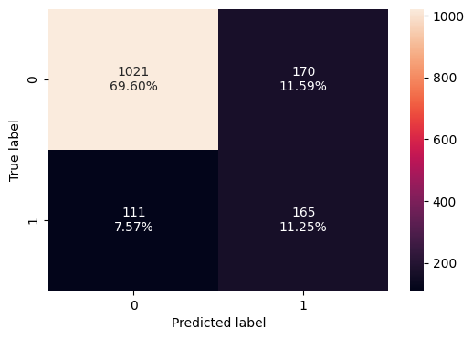

```python
#Calculating different metrics
dtree_estimator_model_train_perf=model_performance_classification_sklearn(d_tree_tuned,X_train,y_train)
print("Training performance:\n",dtree_estimator_model_train_perf)
dtree_estimator_model_test_perf=model_performance_classification_sklearn(d_tree_tuned,X_test,y_test)
print("Testing performance:\n",dtree_estimator_model_test_perf)

#Creating confusion matrix
confusion_matrix_sklearn(d_tree_tuned,X_test,y_test)
```

1. The tuned decision tree model is not overfitting the data as the delta between training and testing data is not huge.
2. The performace of the model is not ideal though. It only has a recall of nearly 60% which means we are loosing opportunites to land new customers with this model.

### Model Building: Random Forest

```
Training performance:
    Accuracy  Recall  Precision   F1
0       1.0     1.0        1.0  1.0
Testing performance:
    Accuracy    Recall  Precision        F1
0  0.921609  0.612319   0.954802  0.746137
```

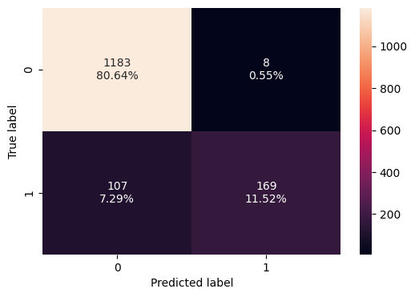

```python
#Fitting the model
r_forest_default = RandomForestClassifier(random_state=1)
r_forest_default.fit(X_train,y_train)

#Calculating different metrics
r_forest_model_train_perf=model_performance_classification_sklearn(r_forest_default,X_train,y_train)
print("Training performance:\n",r_forest_model_train_perf)
r_forest_model_test_perf=model_performance_classification_sklearn(r_forest_default,X_test,y_test)
print("Testing performance:\n",r_forest_model_test_perf)

#Creating confusion matrix
confusion_matrix_sklearn(r_forest_default,X_test,y_test)
```

1. Model is overfit as the delta between the training and test data performace is huge.

### Model Improvement: Random Forest

```python
#Choose the type of classifier.
r_forest_tuned = RandomForestClassifier(class_weight={0:0.18,1:0.82},random_state=1)

# Grid of parameters to choose from
parameters = {
                 'max_depth': [10],
                 'max_features': [None],
                 'min_samples_leaf': [1],
                 'min_samples_split': [7],
                 'n_estimators': [60]
             }


# Type of scoring used to compare parameter combinations
scorer = metrics.make_scorer(metrics.f1_score)

# Run the grid search
grid_obj = GridSearchCV(r_forest_tuned, parameters, scoring=scorer,n_jobs=-1)
grid_obj = grid_obj.fit(X_train, y_train)

# Set the clf to the best combination of parameters
r_forest_tuned = grid_obj.best_estimator_

# Fit the best algorithm to the data.
r_forest_tuned.fit(X_train, y_train)
print(grid_obj.best_params_)
```

```
{'max_depth': 10, 'max_features': None, 'min_samples_leaf': 1, 'min_samples_split': 7, 'n_estimators': 60}
```

```
Training performance:
    Accuracy    Recall  Precision        F1
0  0.979538  0.962733   0.930931  0.946565
Testing performance:
    Accuracy    Recall  Precision        F1
0  0.904567  0.688406   0.778689  0.730769
```

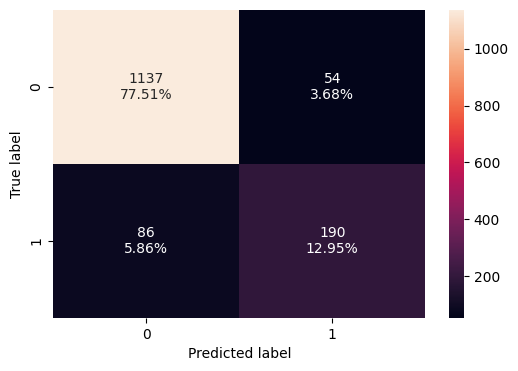

```python
#Calculating different metrics
rf_tuned_model_train_perf=model_performance_classification_sklearn(r_forest_tuned,X_train,y_train)
print("Training performance:\n",rf_tuned_model_train_perf)
rf_tuned_model_test_perf=model_performance_classification_sklearn(r_forest_tuned,X_test,y_test)
print("Testing performance:\n",rf_tuned_model_test_perf)

#Creating confusion matrix
confusion_matrix_sklearn(r_forest_tuned,X_test,y_test)
```

The model is performing better than default parameters.  
Recall on training set is 96 while on testing data set is 68.  
F1 is 94 and 73 with testing and training set  
Indicates overfitting

### Model Building: Bagging

```
   Accuracy    Recall  Precision        F1
0  0.994446  0.975155   0.995246  0.985098
   Accuracy   Recall  Precision        F1
0  0.920927  0.65942   0.892157  0.758333
```

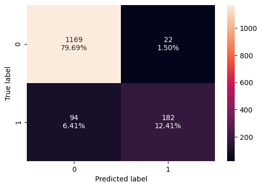

```python
#Fitting the model
bagging_classifier = BaggingClassifier(random_state=1)
bagging_classifier.fit(X_train,y_train)

#Calculating different metrics
bagging_classifier_model_train_perf=model_performance_classification_sklearn(bagging_classifier,X_train,y_train)
print(bagging_classifier_model_train_perf)
bagging_classifier_model_test_perf=model_performance_classification_sklearn(bagging_classifier,X_test,y_test)
print(bagging_classifier_model_test_perf)

#Creating confusion matrix
confusion_matrix_sklearn(bagging_classifier,X_test,y_test)
```

Performance metrics indicate overfitting.  
Model predictions would lead to about 7% loss of opportunity

### Model Improvement: Bagging

```python
# Choose the type of classifier.
bagging_estimator_tuned = BaggingClassifier(random_state=1)

# Grid of parameters to choose from
parameters = {'max_samples': [0.7,0.8,0.9,1],
              'max_features': [0.7,0.8,0.9,1],
              'n_estimators' : [10,20,30,40,50],
             }

# Type of scoring used to compare parameter combinations
scorer = metrics.make_scorer(metrics.f1_score)

# Run the grid search
grid_obj = GridSearchCV(bagging_estimator_tuned, parameters, scoring=scorer,cv=5)
grid_obj = grid_obj.fit(X_train, y_train)

# Set the clf to the best combination of parameters
bagging_estimator_tuned = grid_obj.best_estimator_

# Fit the best algorithm to the data.
bagging_estimator_tuned.fit(X_train, y_train)
```

```
BaggingClassifier(max_features=0.9, max_samples=0.9, n_estimators=50,
                  random_state=1)
```

```
   Accuracy    Recall  Precision        F1
0  0.999708  0.998447        1.0  0.999223
   Accuracy    Recall  Precision        F1
0  0.929789  0.681159   0.926108  0.784969
```

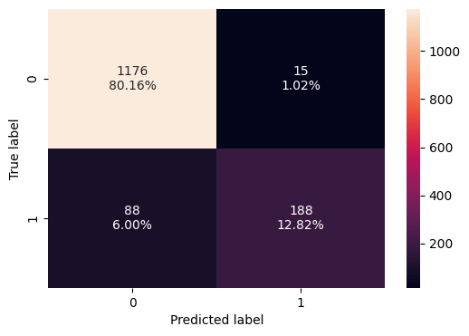

```python
#Calculating different metrics
bagging_estimator_tuned_model_train_perf=model_performance_classification_sklearn(bagging_estimator_tuned,X_train,y_train)
print(bagging_estimator_tuned_model_train_perf)
bagging_estimator_tuned_model_test_perf=model_performance_classification_sklearn(bagging_estimator_tuned,X_test,y_test)
print(bagging_estimator_tuned_model_test_perf)

#Creating confusion matrix
confusion_matrix_sklearn(bagging_estimator_tuned,X_test,y_test)
```

Model is performing very similiar to the original model. overfitting and the recall percentage is not good enough.

### Model Building: AdaBoost

```
   Accuracy    Recall  Precision       F1
0  0.846536  0.299689   0.722846  0.42371
   Accuracy    Recall  Precision        F1
0  0.854124  0.315217   0.776786  0.448454
```

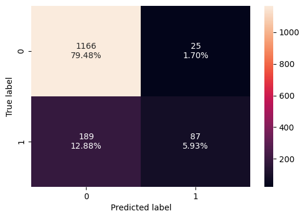

```python
#Fitting the model
ab_classifier = AdaBoostClassifier(random_state=1)
ab_classifier.fit(X_train,y_train)

#Calculating different metrics
ab_classifier_model_train_perf=model_performance_classification_sklearn(ab_classifier,X_train,y_train)
print(ab_classifier_model_train_perf)
ab_classifier_model_test_perf=model_performance_classification_sklearn(ab_classifier,X_test,y_test)
print(ab_classifier_model_test_perf)

#Creating confusion matrix
confusion_matrix_sklearn(ab_classifier,X_test,y_test)
```

Model does not overfit but it gets only 32% recall which is not acceptable.

### Model Improvement: AdaBoost

```python
# Choose the type of classifier.
abc_tuned = AdaBoostClassifier(random_state=1)

# Grid of parameters to choose from
parameters = {
    #Let's try different max_depth for base_estimator
    "base_estimator":[
                      DecisionTreeClassifier(max_depth=3)],
    "n_estimators": [90],
    "learning_rate":np.arange(0.1,2,0.1)
}

# Type of scoring used to compare parameter  combinations
scorer = metrics.make_scorer(metrics.f1_score)

# Run the grid search
grid_obj = GridSearchCV(abc_tuned, parameters, scoring=scorer,cv=5)
grid_obj = grid_obj.fit(X_train, y_train)

# Set the clf to the best combination of parameters
abc_tuned = grid_obj.best_estimator_

# Fit the best algorithm to the data.
abc_tuned.fit(X_train, y_train)
print(grid_obj.best_params_)
```

```
{'base_estimator': DecisionTreeClassifier(max_depth=3), 'learning_rate': 1.1, 'n_estimators': 90}
```

```
   Accuracy   Recall  Precision        F1
0  0.985384  0.93323   0.988487  0.960064
   Accuracy    Recall  Precision        F1
0  0.893661  0.648551   0.752101  0.696498
```

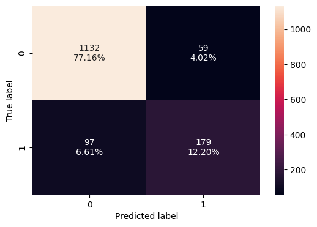

```python
#Calculating different metrics
abc_tuned_model_train_perf=model_performance_classification_sklearn(abc_tuned,X_train,y_train)
print(abc_tuned_model_train_perf)
abc_tuned_model_test_perf=model_performance_classification_sklearn(abc_tuned,X_test,y_test)
print(abc_tuned_model_test_perf)

#Creating confusion matrix
confusion_matrix_sklearn(abc_tuned,X_test,y_test)
```

Model is performing much better but the delta between recall values of traning and testing set is huge suggesting overfitting

### Model Building: Gradient Boosting

```
Training performance:
    Accuracy    Recall  Precision        F1
0  0.887167  0.453416   0.895706  0.602062
Testing performance:
    Accuracy    Recall  Precision        F1
0  0.870484  0.394928   0.825758  0.534314
```

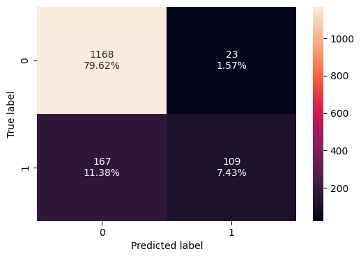

```python
#Fitting the model
gb_classifier = GradientBoostingClassifier(random_state=1)
gb_classifier.fit(X_train,y_train)

#Calculating different metrics
gb_classifier_model_train_perf=model_performance_classification_sklearn(gb_classifier,X_train,y_train)
print("Training performance:\n",gb_classifier_model_train_perf)
gb_classifier_model_test_perf=model_performance_classification_sklearn(gb_classifier,X_test,y_test)
print("Testing performance:\n",gb_classifier_model_test_perf)

#Creating confusion matrix
confusion_matrix_sklearn(gb_classifier,X_test,y_test)
```

Model performace is not great.Althought Accuracy and precision are pretty good, Recall and F1 values are not great.

### Model Improvement: Gradient Boosting

```python
# Choose the type of classifier.
gbc_tuned = GradientBoostingClassifier(init=AdaBoostClassifier(random_state=1),random_state=1)

# Grid of parameters to choose from
parameters = {
    "n_estimators": [100,150,200,250],
    "subsample":[0.8,0.9,1],
    "max_features":[0.7,0.8,0.9,1]
}

# Type of scoring used to compare parameter combinations
scorer = metrics.make_scorer(metrics.f1_score)

# Run the grid search
grid_obj = GridSearchCV(gbc_tuned, parameters, scoring=scorer,cv=5)
grid_obj = grid_obj.fit(X_train, y_train)

# Set the clf to the best combination of parameters
gbc_tuned = grid_obj.best_estimator_

# Fit the best algorithm to the data.
gbc_tuned.fit(X_train, y_train)
```

```
GradientBoostingClassifier(init=AdaBoostClassifier(random_state=1),
                           max_features=0.7, n_estimators=250, random_state=1,
                           subsample=0.9)
```

```
Training performance:
    Accuracy    Recall  Precision        F1
0  0.924583  0.630435   0.953052  0.758879
Testing performance:
    Accuracy    Recall  Precision        F1
0  0.886844  0.507246   0.823529  0.627803
```

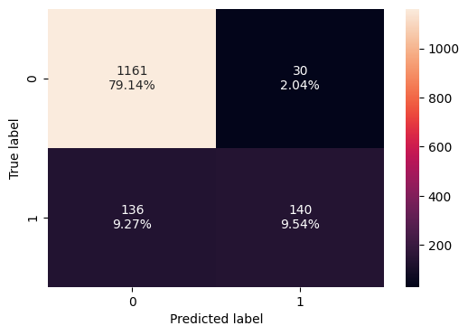

```python
#Calculating different metrics
gbc_tuned_model_train_perf=model_performance_classification_sklearn(gbc_tuned,X_train,y_train)
print("Training performance:\n",gbc_tuned_model_train_perf)
gbc_tuned_model_test_perf=model_performance_classification_sklearn(gbc_tuned,X_test,y_test)
print("Testing performance:\n",gbc_tuned_model_test_perf)

#Creating confusion matrix
confusion_matrix_sklearn(gbc_tuned,X_test,y_test)
```

Perfomance of the model is significantly better but the recall values are not acceptable.  
Model is not overfitting. Precision and accuracy are pertty good, but the F1 and Recall values do not measure up

### Model Building: XGBoost

**Please note XGBoost can take a significantly longer time to run, so if you have time complexity issues then you can avoid tuning XGBoost, and there will no points deducted if XG-boost is not performed**

```
Training performance:
    Accuracy    Recall  Precision        F1
0  0.999708  0.998447        1.0  0.999223
Testing performance:
    Accuracy    Recall  Precision        F1
0  0.929789  0.721014   0.884444  0.794411
```

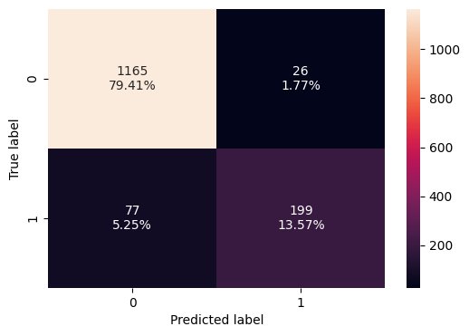

```python
#Fitting the model
xgb_classifier = XGBClassifier(random_state=1, eval_metric='logloss')
xgb_classifier.fit(X_train,y_train)

#Calculating different metrics
xgb_classifier_model_train_perf=model_performance_classification_sklearn(xgb_classifier,X_train,y_train)
print("Training performance:\n",xgb_classifier_model_train_perf)
xgb_classifier_model_test_perf=model_performance_classification_sklearn(xgb_classifier,X_test,y_test)
print("Testing performance:\n",xgb_classifier_model_test_perf)

#Creating confusion matrix
confusion_matrix_sklearn(xgb_classifier,X_test,y_test)
```

Model looks pretty good. Recall and F1 are 72 and 80 percent respectively.  
It does look like model is overfitting though.

### Model Improvement: XGBoost

```python
# Choose the type of classifier.
xgb_tuned = XGBClassifier(random_state=1, eval_metric='logloss')

# Grid of parameters to choose from
parameters = {
    "n_estimators": [45],
    "scale_pos_weight":[5],
    "subsample":[0.7],
    "learning_rate":[0.2],
    "colsample_bytree":[0.9],
    "colsample_bylevel":[0.5,0.7,1]
}

# Type of scoring used to compare parameter combinations
scorer = metrics.make_scorer(metrics.f1_score)

# Run the grid search
grid_obj = GridSearchCV(xgb_tuned, parameters,scoring=scorer,cv=5)
grid_obj = grid_obj.fit(X_train, y_train)

# Set the clf to the best combination of parameters
xgb_tuned = grid_obj.best_estimator_

# Fit the best algorithm to the data.
xgb_tuned.fit(X_train, y_train)
print(grid_obj.best_params_)
```

```
{'colsample_bylevel': 1, 'colsample_bytree': 0.9, 'learning_rate': 0.2, 'n_estimators': 45, 'scale_pos_weight': 5, 'subsample': 0.7}
```

```
Training performance:
    Accuracy    Recall  Precision        F1
0  0.973692  0.986025   0.886872  0.933824
Testing performance:
    Accuracy    Recall  Precision        F1
0   0.90593  0.793478       0.73  0.760417
```

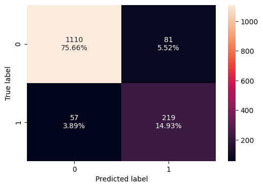

```python
#Calculating different metrics
xgb_tuned_model_train_perf=model_performance_classification_sklearn(xgb_tuned,X_train,y_train)
print("Training performance:\n",xgb_tuned_model_train_perf)
xgb_tuned_model_test_perf=model_performance_classification_sklearn(xgb_tuned,X_test,y_test)
print("Testing performance:\n",xgb_tuned_model_test_perf)

#Creating confusion matrix
confusion_matrix_sklearn(xgb_tuned,X_test,y_test)
```

Model is perfoming better after hyper tuning. Recall is 80% while f1 is 76% on the test data set.

### Model Building: Stacking

```python
estimators = [('Random Forest',r_forest_tuned), ('Gradient Boosting',gbc_tuned), ('Bagging Classifier',bagging_estimator_tuned)]

final_estimator = xgb_tuned

stacking_classifier= StackingClassifier(estimators=estimators,final_estimator=final_estimator)

stacking_classifier.fit(X_train,y_train)
```

```
StackingClassifier(estimators=[('Random Forest',
                                RandomForestClassifier(class_weight={0: 0.18,
                                                                     1: 0.82},
                                                       max_depth=10,
                                                       max_features=None,
                                                       min_samples_split=7,
                                                       n_estimators=60,
                                                       random_state=1)),
                               ('Gradient Boosting',
                                GradientBoostingClassifier(init=AdaBoostClassifier(random_state=1),
                                                           max_features=0.7,
                                                           n_estimators=250,
                                                           random_state=1,
                                                           subsample=0.9)),
                               ('Bagging Classi...
                                                 gpu_id=None, grow_policy=None,
                                                 importance_type=None,
                                                 interaction_constraints=None,
                                                 learning_rate=0.2,
                                                 max_bin=None,
                                                 max_cat_threshold=None,
                                                 max_cat_to_onehot=None,
                                                 max_delta_step=None,
                                                 max_depth=None,
                                                 max_leaves=None,
                                                 min_child_weight=None,
                                                 missing=nan,
                                                 monotone_constraints=None,
                                                 n_estimators=45, n_jobs=None,
                                                 num_parallel_tree=None,
                                                 predictor=None, random_state=1, ...))
```

```
Training performance:
    Accuracy  Recall  Precision       F1
0  0.995323     1.0   0.975758  0.98773
Testing performance:
    Accuracy    Recall  Precision        F1
0  0.910702  0.865942   0.717718  0.784893
```

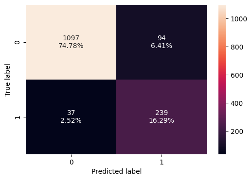

```python
#Calculating different metrics
stacking_classifier_model_train_perf=model_performance_classification_sklearn(stacking_classifier,X_train,y_train)
print("Training performance:\n",stacking_classifier_model_train_perf)
stacking_classifier_model_test_perf=model_performance_classification_sklearn(stacking_classifier,X_test,y_test)
print("Testing performance:\n",stacking_classifier_model_test_perf)

#Creating confusion matrix
confusion_matrix_sklearn(stacking_classifier,X_test,y_test)
```

This Model is perfoming the best of all the models we have built. Recall of the test data set is at 87%.

## Model Comparison and Final Model Selection

```python
# training performance comparison

models_train_comp_df = pd.concat(
    [d_tree_model_train_perf.T,dtree_estimator_model_train_perf.T,r_forest_model_train_perf.T,rf_tuned_model_train_perf.T,
     bagging_classifier_model_train_perf.T,bagging_estimator_tuned_model_train_perf.T,ab_classifier_model_train_perf.T,
     abc_tuned_model_train_perf.T,gb_classifier_model_train_perf.T,gbc_tuned_model_train_perf.T,xgb_classifier_model_train_perf.T,
    xgb_tuned_model_train_perf.T,stacking_classifier_model_train_perf.T],
    axis=1,
)
models_train_comp_df.columns = [
    "Decision Tree",
    "Decision Tree Estimator",
    "Random Forest Estimator",
    "Random Forest Tuned",
    "Bagging Classifier",
    "Bagging Estimator Tuned",
    "Adaboost Classifier",
    "Adabosst Classifier Tuned",
    "Gradient Boost Classifier",
    "Gradient Boost Classifier Tuned",
    "XGBoost Classifier",
    "XGBoost Classifier Tuned",
    "Stacking Classifier"]
print("Training performance comparison:")
models_train_comp_df
```

```
Training performance comparison:
```

|  | Decision Tree | Decision Tree Estimator | Random Forest Estimator | Random Forest Tuned | Bagging Classifier | Bagging Estimator Tuned | Adaboost Classifier | Adabosst Classifier Tuned | Gradient Boost Classifier | Gradient Boost Classifier Tuned | XGBoost Classifier | XGBoost Classifier Tuned | Stacking Classifier |
| --- | --- | --- | --- | --- | --- | --- | --- | --- | --- | --- | --- | --- | --- |
| Accuracy | 1.0 | 0.785151 | 1.0 | 0.979538 | 0.994446 | 0.999708 | 0.846536 | 0.985384 | 0.887167 | 0.924583 | 0.999708 | 0.973692 | 0.995323 |
| Recall | 1.0 | 0.579193 | 1.0 | 0.962733 | 0.975155 | 0.998447 | 0.299689 | 0.933230 | 0.453416 | 0.630435 | 0.998447 | 0.986025 | 1.000000 |
| Precision | 1.0 | 0.445639 | 1.0 | 0.930931 | 0.995246 | 1.000000 | 0.722846 | 0.988487 | 0.895706 | 0.953052 | 1.000000 | 0.886872 | 0.975758 |
| F1 | 1.0 | 0.503714 | 1.0 | 0.946565 | 0.985098 | 0.999223 | 0.423710 | 0.960064 | 0.602062 | 0.758879 | 0.999223 | 0.933824 | 0.987730 |

```python
# testing performance comparison

models_test_comp_df = pd.concat(
    [d_tree_model_test_perf.T,dtree_estimator_model_test_perf.T,r_forest_model_test_perf.T,rf_tuned_model_test_perf.T,
     bagging_classifier_model_test_perf.T,bagging_estimator_tuned_model_test_perf.T,ab_classifier_model_test_perf.T,
     abc_tuned_model_test_perf.T,gb_classifier_model_test_perf.T,gbc_tuned_model_test_perf.T,xgb_classifier_model_test_perf.T,
    xgb_tuned_model_test_perf.T,stacking_classifier_model_test_perf.T],
    axis=1,
)
models_test_comp_df.columns = [
    "Decision Tree",
    "Decision Tree Estimator",
    "Random Forest Estimator",
    "Random Forest Tuned",
    "Bagging Classifier",
    "Bagging Estimator Tuned",
    "Adaboost Classifier",
    "Adabosst Classifier Tuned",
    "Gradient Boost Classifier",
    "Gradient Boost Classifier Tuned",
    "XGBoost Classifier",
    "XGBoost Classifier Tuned",
    "Stacking Classifier"]
print("Testing performance comparison:")
models_test_comp_df
```

```
Testing performance comparison:
```

|  | Decision Tree | Decision Tree Estimator | Random Forest Estimator | Random Forest Tuned | Bagging Classifier | Bagging Estimator Tuned | Adaboost Classifier | Adabosst Classifier Tuned | Gradient Boost Classifier | Gradient Boost Classifier Tuned | XGBoost Classifier | XGBoost Classifier Tuned | Stacking Classifier |
| --- | --- | --- | --- | --- | --- | --- | --- | --- | --- | --- | --- | --- | --- |
| Accuracy | 0.886844 | 0.808453 | 0.921609 | 0.904567 | 0.920927 | 0.929789 | 0.854124 | 0.893661 | 0.870484 | 0.886844 | 0.929789 | 0.905930 | 0.910702 |
| Recall | 0.706522 | 0.597826 | 0.612319 | 0.688406 | 0.659420 | 0.681159 | 0.315217 | 0.648551 | 0.394928 | 0.507246 | 0.721014 | 0.793478 | 0.865942 |
| Precision | 0.696429 | 0.492537 | 0.954802 | 0.778689 | 0.892157 | 0.926108 | 0.776786 | 0.752101 | 0.825758 | 0.823529 | 0.884444 | 0.730000 | 0.717718 |
| F1 | 0.701439 | 0.540098 | 0.746137 | 0.730769 | 0.758333 | 0.784969 | 0.448454 | 0.696498 | 0.534314 | 0.627803 | 0.794411 | 0.760417 | 0.784893 |

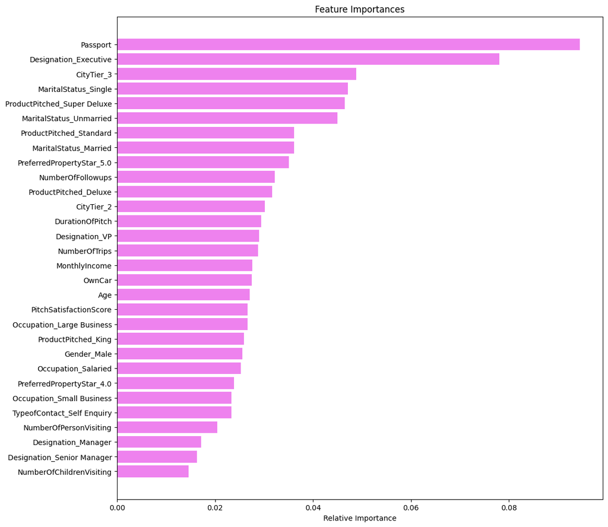

```python
feature_names = X_train.columns
importances = xgb_tuned.feature_importances_
indices = np.argsort(importances)

plt.figure(figsize=(12,12))
plt.title('Feature Importances')
plt.barh(range(len(indices)), importances[indices], color='violet', align='center')
plt.yticks(range(len(indices)), [feature_names[i] for i in indices])
plt.xlabel('Relative Importance')
plt.show()
```

1) Customers posessing passports or not serves as a efficeint indicator.  
2) Customers who occupy executive positions tend to take the package  
3) Customers who are single and unmarried also have high impact on the results of the model.

## Actionable Insights and Business Recommendations

**What recommedations would you suggest to the Visit with us company?**

- As the most impactful features that determine the sucess of the models are
1. Possession of passport
2. Executive designation
3. Tier 3 cities
4. Single

Marketting should be done to target these kinds of customers.

- Small families tend to travel more.
- Larger families can be given deals that help them accomodate thier faimilis and helps them make the trip.
- Follow up calls make a difference. Stress should be placed on scheduling follow up calls to help customers make the call
- Target Tier 1 and Tier 3 cities for better results
- Targeted campaigns towards young families should help increase sales.
- Customers in the 25-40 age rage travel the most. Adding features to the new package that caters to this age group and marketted as such would help drive up the sales.